# Neural Codes: The Language of Thought

Michelle R. Greene

Winter 2019

Instructor: Michelle R. Greene, Ph.D

Email: mgreene2@bates.edu

Office hours: MWF 9:30-10:30; TTh 8:00-10:00 Hathorn 106  
If neither of these times work, please know that I’m happy to meet when my door is open!

Logistics: MWF 8:25am - 9:20 (Carnegie 115)

Prerequisites: NS/PY 160 or 200

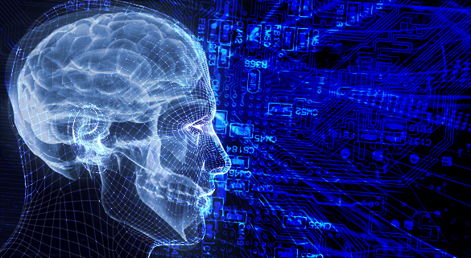

# Course Description

Although a central tenet of neuroscience is that information about the world in encoded in the patterns of neural firing, it is increasingly acknowledged that our assumptions about these patterns make qualitatively different predictions about neural function. This course examines major hypotheses related to information coding by individual neurons and populations of neurons. Specific themes include rate coding versus time-based codes, sparse versus dense codes, and the relationship between brain responses and the statistics of their inputs. Students examine biological data and artificial models to assess how various encoding schemes might produce skillful behavioral responses.

# Introduction

What is a “neural code”? This fundamental concept refers to the rules that transform action potentials into perceptions, concepts, memories, emotions, and actions. The neural code is the software of the brain.

Solving the neural code is the deepest, most consequential problem in neuroscience. Cracking this code will give us unlimited control over our own brains, allowing us to “fix” brains that have been broken through stroke or other injury. It will allow us to truly read minds, let us share our thoughts with others remotely, or even upload our consciousness when we die. More broadly, understanding the code will help us solve long-standing philosophical mysteries such as the mind-body problem and the existence of free will.

Just as solving the genetic code over half a century ago led to an understanding of human variability and disease and has paved the way for editing this code using techniques such as CRISPR-CAS9, solving the neural code will be just as transformative in the next century. In fact, Francis Crick, who co-discovered of the genetic code, spent the second half of his career working on the neural code.

We are still in relatively early days of this endeavor. Currently, we do not have a single neural code, but many. There are rate codes, temporal codes, population codes and grandmother-cell codes, quantum and chaotic and information codes, and codes based on oscillations and synchronies. In this course, we will explore many of these codes with an eye to how specific codes would enable the brain to efficiently solve hard problems.

# Learning Objectives:

By the end of this course, you will be able to:

- Explain the concept of *information* and describe how one might compute it mathematically from probabilities.
- Explain the concept of a *representation* and be able to distinguish between a representation’s content and its function.
- Identify constraints that place bounds on the types of neural codes that can exist.
- Compare and contrast competing theories of neural coding, evaluating their comparative strengths and tradeoffs.

# Policies and Expectations:

## Commitment to Inclusion

I expect all students to be respectful of the widely varied experiences and backgrounds represented by classroom members. Disrespect or discrimination on any basis will not be tolerated. Whether inside or outside the classroom, if you encounter sexual harassment, sexual violence, or discrimination based on race, color, religion, age, national origin, ancestry, sex, sexual orientation, gender identity/expression, or disability, you are encouraged to report it to Gwen Lexow, Director of Title IX and Civil Rights Compliance at Bates at glexow@bates.edu or 207-786-6445. Additionally, please remember that Bates faculty are concerned about your well-being and development, and we are available to discuss any concerns you have. Students should be aware that faculty are legally obligated to share disclosures of sexual violence, sexual harassment, relationship violence, and stalking with the college’s Title IX Officer to help ensure that your safety and welfare are being addressed.

## Academic Integrity

Please remind yourself of the [Bates College policy on academic integrity](http://www.bates.edu/student-affairs/student-conduct/academic-integrity-policy/). Please read this guide and its definitions of plagiarism, use/misuse of sources, and cheating. Students’ work will be closely scrutinized for plagiarism and violations of the College policy will not be tolerated. If you are concerned that your collaboration might put you at risk of an academic integrity violation, please come see me during office hours as soon as possible.

## Students with Learning Differences

If you have a condition or disability that creates difficulties with the assignments, please notify me as soon as possible. You will need to create documentation with the [Office of the Dean of Students](http://www.bates.edu/accessible-education/), so if you need accommodation, please do this as soon as possible.

## Late Work

For all of our deadlines, if you turn in a component late, you will lose 10% of the total score per day. For example, the maximum possible percentage for a product turned in one day late is 90. This policy does not apply to a documented personal or family emergency.

## Emergencies

If I must cancel class due to weather or an emergency, I will inform you via the class email list. Please consider your Bates email to be the default place to look for class-related information and get into the habit of checking it daily.

## Electronics

Please silence your cell phone upon entering class and refrain from using it during class. **In general, this is a laptop-free classroom**. There are good reasons for this: laptop use is correlated with lower learning outcomes for you and those around you, and the act of taking notes on the laptop is less effective than hand-written notes. There will be exceptions to this rule for various activities, and these will be advertised in advance.

# Grading

**Homework: 40% of total**  
Starting on the second class period, there will be a set of questions about the reading to guide your preparation. One of the questions will be selected for you to answer on a notecard at the beginning of each class. These will be graded on a 0-3 scale as follows: 0: Absent; 1: Major errors; 2: Good (modal grade); 3: Exceptionally good answer. (You should consider 3 to be extra credit). **Your lowest two grades will be dropped, and no make up is available for these questions.** Although you are not required to turn in an answer for all questions, preparing your answers as you go will make your life easier as you study for exams! Note: 40%/32 class sessions = 1.25% of your total grade per session.

**Exams: 30% of total**  
The two exams will be given in class and will include a mix of multiple-choice, fill-in, and short answer questions. I will return the graded exam to you within one week. If you are not happy with your grade, you will have the opportunity to make corrections on the exam to earn back half of the lost points. For example, if you earned a 70 on an exam, you will be able to earn up to an 85 by doing corrections.

- **Exam 1: February 8** Will cover foundational materials (codes, information, and representations).
- **Exam 2: March 11** Will cover codes for single neurons and neuronal populations.

**Take-home final: 20% of total**  
The final exam for this course is cumulative and open resource (open note, open reading, open collaboration). It will be released after the last class meeting on April 5, and will be due on Lyceum at the end of the scheduled final exam time: **April 9 3:15pm**.

**Participation: 10% of total**  
Learning is not a spectator event: you need to ask questions. If you are confused about something, odds are good that you are not the only one. Questions also serve a more fundamental role in memory encoding and learning. If you are thinking about questions, you are integrating what you are learning into your existing knowledge structures. Questions often lead to creative scientific thought. This is an active classroom. If you come to class ready to work, ask questions, experiment, and help your classmates then this is 10% of your grade that you will not need to worry about.

Your final percentage score will be assigned a letter grade on the following scale:

| Grade | Percentage |  | Grade | Percentage |
| --- | --- | --- | --- | --- |
| A+ | >95% |  | B- | 71-74% |
| A | 87-94% |  | C+ | 67-70% |
| A- | 83-86% |  | C | 63-66% |
| B+ | 79-82% |  | D | 50-62% |
| B | 75-78% |  | F | <50 |

# **Reading**:

All required papers will be available on this website and Lyceum, and should be done before class.

# Course Calendar

## Unit 1: Foundational Materials

### Week 1: What is a code?

January 7: Introduction

January 9: What is a code?

- Read: Sharon Bertsch McGrayne [“Bayes Goes to War”](https://drive.google.com/open?id=1cH-xeVHvIgPv5D0FgSg-U2XF4OSgTKas) from *The Theory that Would Not Die*
- Optional reading: Your main reading speaks a lot about Bayes’ Theorem. While you don’t need to know it for this class, if you are curious about learning more, I recommend [this article](https://www.bayestheorem.net/).
- Study question 1: What are at least three different forms of information that researchers at Bletchley Park used to decode messages encrypted by the Germans?
- Study question 2: Alan Turing invented the *ban*, a measurement of subjective belief. Is this a unit of probability? Why or why not?
- Study question 3: What makes deciphering the brain’s code easier than the wartime scenario described in your reading? What makes it harder?

January 11: What is a neural code?

- Read: Jerome Lettvin et al [“What the Frog’s Eye Tells the Frog’s Brain”](https://drive.google.com/file/d/1ZIl_xRlB547WCE3bZAlWrlLtyXDMFTIa/view?usp=sharing).
- Study question 1: “The connections are such that there is a synaptic path from a rod or cone to a great many ganglion cells, and a ganglion cell receives paths from a great many thousand receptors. Clearly, such an arragement would not allow for good resolution were the retina meant to map an image in terms of light intensity point by point”. Why is this the case? What alternative arrangement would provide a more photograph-like representation?
- Study question 2: What is the “code” that seems to be “spoken” by ON, ON-OFF, and OFF cells?
- Study question 3: The researchers’ strategy was to “present the frog with as wide a range of visible stimuli as we could”. What do you think of this approach? What sort of biases might be introduced into the results?

### Week 2: What is information?

January 14: What is information, part 1

- Read: Pierce [“The Origins of Information Theory”](https://drive.google.com/file/d/155IJ4piGMWK7WCiKJ-JmSRuztN5u2wIy/view?usp=sharing) from *An Introduction to Information Theory: Symbols, Signals, and Noise*
- Study question 1: Your reading discusses entropy in both the thermodynamic sense as well as the information/communication sense. What fundamental similarity do these two senses share?
- Study question 2: “The more we know about what message the source will produce, the less uncertainty, the less the entropy, and the less the information”. Please explain how knowing more about a message means less information.
- Study question 3: Edison’s quadruplex telegraph system enabled the simultaneous encoding and decoding of two messages. Describe how one would have to change the system to scale the system to three messages.
- Study question 4: When sending messages via telegraphy, engineers had to deal with noise over the cables and lines. Think about neurons sending messages down axons. What types of noise might exist? What properties of neurons ameliorate some of these issues?

January 16: What is information, part 2

- Read: Stone [“Information Theory”](https://drive.google.com/file/d/1eMVkkX4RfwVjTBtLkYjWmwk_2uhUT68W/view?usp=sharing) from *Principles of Neural Information Theory: Computational Neuroscience and Metabolic Efficiency*
- Study question 1: Consider Figure 2.3a from your reading, and consider it within the specific context of a random variable, such as the outcome of a coin toss. What does it mean to say that Shannon information is a unit of surprise?
- What is the entropy of a six-sided die?
- Let’s say that there are 1800 students at Bates College, and 60 of them are neuroscience majors. What is the entropy of the college, and what is the entropy of neuroscience majors?

January 18: What is information, part 3

- Read: review this week’s papers
- Optional reading: Heeger [Signal Detection Theory](http://www.cns.nyu.edu/~david/handouts/sdt/sdt.html)
- Consider [this image](https://drive.google.com/open?id=1GlW7hk4_Mi2iQ2o9DJwM90nB7XRvR0xR). The top distribution is known as a *uniform* distribution, and the bottom is called a *normal* or *gaussian* distribution. Which one has higher entropy? Why?
- How many possible objects could be guessed in a game of 20 questions?

### Week 3: What is a representation?

January 21: **NO CLASS: [MLK DAY](http://www.bates.edu/mlk/)**

January 23: The signal and the noise: signal detection theory

- Read: Heeger [Signal Detection Theory](http://www.cns.nyu.edu/~david/handouts/sdt/sdt.html)
- Review: Stone [“Information Theory”](https://drive.google.com/file/d/1eMVkkX4RfwVjTBtLkYjWmwk_2uhUT68W/view?usp=sharing) from *Principles of Neural Information Theory: Computational Neuroscience and Metabolic Efficiency*, pages 17-22.
- Study question 1: Pay particular attention to the first paragraph of section 2.5 (p.17). Why are consecutive natural signals usually correlated? Provide at least two examples from different sensory modalities.
- Study question 2: Why is it the case that H(y|x)=0 when there is no noise?
- Study question 3: Define the criterion in signal detection theory. Give an example of a situation in which one would want to bias the criterion towards misses, and another situation in which one would want to bias it towards false alarms.

January 25: Content of representations: theory and examples

- Read: J.J. Gibson [“The Environment as a Source of Stimulation”](https://drive.google.com/open?id=11M9iOBIreqVe4yIccx1t_0XWepA7c6EE) from *The Senses Considered as Perceptual Systems* * Study question 1: Throughout the chapter, Gibson uses in the word “information”, but does not use any of the formalisms that we’ve been discussing. Is his view of information compatible with information theory? What would we need to know in order to develop a formalized theory of sensory information?
- Study question 2: As students of the perceptual systems, Gibson encourages us to focus on a physics that describes physical phenomena at spatial scales relevant to animals (millimeters to kilometers). Provide one example of a situation in which this simplification adds to our understanding of sensory stimulation, and one example where it does not.
- Study question 3: The chapter notes that as terrestrial animals, we are subject to atmospheric pressure. Why are we not explicitly aware of this constant stimulation?
- Study question 4: Gibson describes language and visual art as second-order sources of information. What does this mean? What would be the primary source of information as you read these words?

### Week 4: How do representations function?

January 28: Functions of representations, part 1

- Read: Kersten (1987) [Predictability and redundancy of natural images](https://drive.google.com/file/d/12Zvfqe3305OU29UvQxi2HgMqE0exXoPB/view?usp=sharing)
- Optional reading: Shannon (1951) [Prediction and entropy of written English](https://drive.google.com/file/d/1NH4JQjFzlUt1V4-FlICPPpcIkR0KqGKr/view?usp=sharing)
- Study question 1: Kersten uses images that were 128x128 pixels in size, and could take one of 16 different gray level values. How many possible images could be created with these parameters?
- Study question 2: Kersten used photographs as a proxy for the visual world. In last week’s readings, Gibson defined visual images as second-order information sources. Provide one argument that photographs are a defensible proxy, and one counter-argument that they are not.
- Study question 3: Both Shannon (optional reading) and Kersten use human judgments to measure entropy. Why is this necessary?
- Study question 4: Design an experiment in which the entropy of another sense could be measured.

January 30: Functions of representations, part 2

- Read: Ballard [“On the Function of Visual Representation”](https://drive.google.com/file/d/1WYidxTnsPsH1GOK3OD43oTpmgqwCNkFg/view?usp=sharing)
- Recommended reading: Marr (1982) [“The Philosophy of the Approach”](https://drive.google.com/open?id=1V9g_95BEz52WEmuVbGI14Fegd879w5tQ) Especially section 1.2.
- Study question 1: Ballard notes that most researchers in visual perception take a *literalist* view of perception. How does Ballard define the literalist view?
- Study question 2: Name two pieces of evidence that call the literalist view into question.
- Study question 3: What other evidence have we considered this semester that questions the literalist view?

February 1: How do we speak about representations?

- Read: Vilarroya (2017) [Neural Representation: A Survey-Based Analysis of the Notion.](https://www.frontiersin.org/articles/10.3389/fpsyg.2017.01458/full)
- Read: Use [Google Scholar](https://scholar.google.com/) to find an neuroscience article from the past 5 years that makes a claim about a neural representation. We will be doing an in-class journal club on your findings.
- Study question: Critique your article’s use of “representation” using the criteria outlined by Vilarroya.

### Week 5: What is computation?

February 4: Computations and transformations

- Read: Singer, [“New clues to the mystery of how our brains keep time”](https://www.wired.com/2016/02/new-clues-to-the-mystery-of-how-our-brains-keep-time/) *Wired*
- Read: DiCarlo & Cox (2007) [Untangling invariant object recognition.](https://drive.google.com/file/d/1kQVoDBEbRbOaYW1M9OYAuLvzCn_3fKzM/view?usp=sharing) *Trends in Cognitive Science*
- Study question 1: “Object recognition is hard because useful forms of visual representation are hard to build.” Name 2-3 factors that make the retinal representation not particularly useful for object recognition.
- Study question 2: DiCarlo and Cox write about a “manifold” that describes all possible transformations of a visual stimulus, such as a face. Extend this idea into the auditory domain. What might the axes be of a space that represents all possible transformations of the spoken word “cat”? (i.e. all voices, accents, etc).
- Study question 3: In the earliest visual transformations, 100 million photoreceptors project onto one 1 million retinal ganglion cells. These 1 million cells then project to 100 million in primary visual cortex (V1). Does this mean that V1 has a higher entropy than retinal ganglion cells? Why or why not?

February 6: Review and reflection

- No homework for this class period, but come prepared with your questions for the exam.

February 8: **EXAM 1**

## Unit 2: Codes for Single Neurons and Neuron Populations

### Week 6: What does a single neuron know?

February 11: Grandmother cells, part 1

- Read: Gross (2002) [Geneology of the “grandmother cell”](http://www.cs.utexas.edu/~dana/Gross.pdf)
- Study question 1: What is a “grandmother cell”? What do these cells respond to?
- Study question 2: What is the labeled line theory of neural function? How does it relate to the theory of “grandmother cells”?

February 13: Grandmother cells, part 2

- Read: Quiroga et al (2005) [Invariant visual representation by single neurons in the human brain.](http://www.hms.harvard.edu/bss/neuro/bornlab/nb204/papers/quiroga-etal-nature2005.pdf)
- Study question 1: Briefly describe the methodology of these experiments: who were the observers? Where in the brain were the recordings made? What stimuli were the observers shown?
- Study question 2: The researchers used ROC analysis in order to test the selectivity of the cells they recorded from. What counted as a “hit” and a “false positive” in this analysis?
- Study question 3: Consider the “Jennifer Aniston” neuron presented in Figure 1 and the “Halle Barry” neuron presented in Figure 2. Which neuron seems more like a grandmother cell? Why?

February 15: Grandmother cells, part 3

- Read: [Excerpts](https://drive.google.com/file/d/1tl5F7WlZ9Ozun7oq8tbMfch2Rdz3ts2J/view?usp=sharing) from Anderson *An Introduction to Neural Networks*, chapter 10.
- Study question 1: List four issues with grandmother cell representations. Which seems the most serious to you? Which seems the least serious? Why?
- Study question 2: Your reading describes similarity as a “tricky” concept. Describe in detail one example where “similarity” is not a singular or straightforward concept.
- Study question 3: For each of the five desirable properties of data representations, provide an example of this in the brain. For example, under the first property (similar events should give rise to similar representations), you might point to the fact that pattern classification algorithms are able to predict what one was seeing, thinking, or doing based on brain data. This means observed neural patterns generalize to new examples.

### Week 7: **WINTER RECESS**

### Week 8: What does a population of neurons know?

February 25: Local versus distributed codes

- Read: Thorpe (1989) [Local versus distributed coding](https://drive.google.com/open?id=1P1fwlGnrmWgb6jNd1TPleHRuD5GjcMnc) *Intellectica*
- Study question 1: Explain the difference between value coding and variable coding, as attributed to Ballard.
- Study question 2: Is the labeled line hypothesis a local or distributed code? Why?
- Study question 3: One of the arguments against local coding is that there are too many neurons that would be required. Explain why this line of reasoning is fallacious.
- Study question 4: Local coding schemes are often criticized for being fragile, meaning that any loss of a neuron could lead to catastrophic results. Thorpe shows that distributed coding schemes might be even worse. Explain this argument.
- Class activity: [here is a link](https://en.wikipedia.org/w/api.php?action=query&list=random&rnlimit=20&rnnamespace=0) that shows you 20 random articles from Wikipedia

February 27: Coarse, distributed codes in theory

- Read: Hinton, McClelland, and Rumelhart [Chapter 1](https://drive.google.com/open?id=18Fb7ICbzygdUEadefdEW5rvjfNaF9Bmd), *Parallel Distributed Processing*
- Study question 1: Figure 2 demonstrates some of the contextual influences on reading. Imagine that the letters with ink splotches were entirely missing - would the letters be similarly easy to guess? What information are you using to perform the task?
- Study question 2: The chapter discusses *frames*, *scripts*, or *schemata* (synonymous terms for our purposes). What is in your script for a college course?
- Study question 3: Define what a *pattern associator* is, and show an example in matrix form.

March 1: Coarse, distributed codes in practice

- Read: Georgeopoulos (1986) [Neural Coding of Movement Direction](https://drive.google.com/file/d/1T5yALmhb1pyOLdssXk8uOdddu0dDKB5N/view?usp=sharing) *Science*
- Study question 1: Explain the finding depicted in Figure 1. In what other sensory system have we previously seen a similar type of tuning?
- Study question 2: Explain the finding depicted in Figure 3. How was the population vector obtained?
- Study question 3: Are there any biases in the data collection methods that could have influenced this result? What are they?

### Week 9: Time-based codes

March 4: Introduction to time-based codes

- Read: Gerster [“How can brains be so fast?”](https://drive.google.com/file/d/1hHBvweYtYMhbFvrRcTGVmXbvwBl090kA/view?usp=sharing) from *23 Problems in Systems Neuroscience*
- Study question 1: Explain how the speed of neural processing is limited by the the dynamics of membrane responses and synaptic response. What causes these responses to lag in time?
- Study question 2: Explain why a “naive” rate coding scheme with a 100 ms integration window would only allow the brain to process at slower than 10 Hz.
- Study question 3: “Given the large number of neurons in the cortex, another potential coding scheme seems to be a ‘rate’ defined by a population average rather than a temporal average”. If this is the case, would this be a local code, a distributed code, or could it be either? Explain your reasoning.
- Study question 4: Explain how having a small amount of baseline firing can effectively reduce the membrane time constant.

March 6: Examples of time-based codes

- Read: Van Rullen et al (2005) [Spike times make sense.](https://drive.google.com/file/d/1wIvQ0bdivQcKRjLY01IUhlFpo-WBrKie/view?usp=sharing) *Trends in Neurosciences*
- Study question 1: Describe the experiment cited by the authors on page 1 that provides evidence for information being carried in a “time-to-first-spike” manner. What is the evidence that this code is reliable?
- Study question 2: Time-based codes are often criticized for being too unreliable due to the natural variability of neural firing. To address this issue, Van Rullen writes “a spike that would be precisely timed with respect to an internal event to which the experimenter does not have access will be considered, by default, as unreliable.” List two types of internal events that he might be referring to.
- Study question 3: One other issue with time-based codes is that they seem to require a mechanism to keep track of event times and to reset after previous events. What two mechanisms does Van Rullen suggest?

March 8: The binding problem

- Read: Treisman (1999) [Solutions to the binding problem: progress through controversy and convergence.](https://drive.google.com/file/d/1SgH4Q6FSqxmAv3jyJR048uLgJKRAWU18/view?usp=sharing) *Neuron*
- Study question 1: What is the binding problem?
- Study question 2: Treisman distinguishes between three different levels of explanation for the binding problem: parsing, encoding, and structural description. Provide an example of a theory that primarily addresses each of these levels.
- Study question 3: In many of the theories that are reviewed in this paper, *time* seems to be a major part of the solution. Compare and contrast two different theories that use time to solve the binding problem.

## Unit 3: Why does the brain code like this?

### Week 10: What might we be missing?

March 11: **EXAM 2**

March 13: Biases in data collection

- Read: Olshausen & Field [“What’s the other 85% of V1 doing?”](http://www.rctn.org/bruno/papers/V1-chapter.pdf) From *23 Problems in Systems Neuroscience*
- Study note: the article frequency references *Gabor functions* - these are the product of a [sine wave and a Gaussian](https://en.wikipedia.org/wiki/Gabor_filter).
- Study question 1: Describe the biases that we face in neuron sampling? What causes these biases?
- Study question 2: Describe the biases that we have from the stimuli that are shown to experimental subjects. What might be a way of ameliorating these issues?
- Study question 3: Describe what is meant by a “classical receptive field”. Describe a result that challenges this notion.

March 15: Homunculus problem

- Read: Rieke (1997) [Introduction](https://drive.google.com/file/d/1ZsYOtCOHHth4W4wxWos8jcp7BjNSzx43/view) from *Spikes*, section 1.2 required. Others recommended.
- Read: Dennett & Kisborne (1992) [Time and the Observer: The Where and When of Consciousness in the Brain.](https://ase.tufts.edu/cogstud/dennett/papers/Time_and_the_Observer.pdf). Section 1 required. Others optional.
- Study question 1: Explain the problems of the homunculus / Cartestian theatre.
- Study question 2: By contrast, what is the “multiple drafts” theory of consciousness? How does it characterize the observer’s “stream of consciousness”?
- Study question 3: Imagine that you are reading a journal article about a neural decoding study that shows that *information* about entity X can be read out from brain area Y (e.g. face identity information in the fusiform gyrus). Is it reasonable to infer that brain area Y is recognizing entity X? Why or why not?

### Week 11: What are the constraints on the brain’s representations?

March 18: Why do we have brains?

- Read: Sterling & Laughlin [“Why an Animal Needs a Brain”](https://drive.google.com/file/d/13kVVq3LjCaF2vgo8QDzSgA04Z2Hr2pO_/view?usp=sharing) from *Principles of Neural Design*
- Study question 1: Consider the “behaviors” evident in a single-celled bacterium such as *E. coli*. How is it able to perceive, move, and remember without a brain? How are memories stored in the organism?
- Study question 2: Why is a longer memory of no advantage to a single-celled organism such as *E. coli* or *Paramecium*?
- Study question 3: Why are fewer synapses less reliable in general? What trade-off does *C Elegans* make to “get away with” so few synapses?
- Study question 4: Why is it an advantage for an organism to minimize “wiring” length - i.e. the length of axons?
- Reflection question (not for notecard): Does *C. Elegans* experience pleasure?

March 20: Metabolic demands on the brain, part 1

- Read: Attwell & Laughlin (2001) [An Energy Budget for Signaling in the Grey Matter of the Brain](https://drive.google.com/file/d/1IRxObPOU0jnqzv8ZINfqopVj6zPQaPnQ/view?usp=sharing) *Journal of Cerebral Blood Flow and Metabolism* (The calculations on page 1134 are an optional quantitative adventure)
- Study question 1: If 200,000 Na+ enter the post-synaptic neuron, why are 67,000 ATP required to evict them via Na+/K+ pumps?
- Study question 2 Pay particular attention to the section “Distributed coding, energy use, and coding sparseness”. Although we will cover the calculations in detail in the class, have a sense of whether *local* or *distributed* codes are more energy efficient and why.
- Study question 3: What are some of the simplifying assumptions made by this work? Will they systematically overestimate or underestimate energy consumption?
- Optional pondering: if 3x10^9 ATP are used per neuron, per second; and if 1 mole of ATP contains 30.5 kJ or 7.5 kcal of energy, how many kcal of food is necessary just to power your brain for a day?

March 22: Metabolic demands on the brain, part 2

- Read: Lennie (2003) [The Cost of Cortical Computation](http://www2.bcs.rochester.edu/sites/plennie/pdfs/Lennie03a.pdf) *Current Biology*
- Study question 1: Name one known difference between human and rodent brains that makes Lennie’s calculations of neural energy use different from those of Attwell & Laughlin from Wednesday’s reading.
- Study question 2: Describe the methodology that Lennie used to estimate the *sustainable spike rate*.
- Study question 3: Name one fundamental agreement between the Lennie’s analysis and that of Attwell & Laughlin.

### Week 12: A mirror held up to the world: coding the redundancy of the world

March 25: Redundancy in the environment

- Read: Attneave (1954) [Some Informational Aspects of Visual Perception](https://drive.google.com/open?id=1nSj7smi7bP3ixAw9NXqyFOghXuTlDn0L) *Psychological Review*
- Study question 1: What does Attneave mean when he considers the visual world to be redundant?
- Study question 2: In what ways is the thought experiment presented on pages 1-2 similar to the actual experiment run by Kersten that we read earlier in the semester? In what ways is it different?
- Study question 3: Use the Hartley equation to verify the maximum entropy that Attneave calculated in footnote 4.
- Study question 4: “A troublesome question arises:…where does perception leave off and inductive reasoning begin?” What are some other ways in which you have seen this line blurred this semester?
- Study question 5: Solve the following paradox: how is it that a redundant figure, such as that in Figure 1 as well as a non-redundant figure, such as that in Figure 4, both be perceived as homogenous?

March 27: Compact codes

- Read: Barlow (1961) [Possible Principles Underlying the Transformations of Sensory Messages](http://www.cnbc.cmu.edu/~tai/microns_papers/Barlow-SensoryCommunication-1961.pdf)
- Study question 1: Describe the “password hypothesis” put forth by Barlow. Describe one feature or entity that you would test as a possible “password” for human observers. (This second part cannot be found in the paper and is for your reflection).
- Study question 2: Barlow articulates the redundancy reduction hypothesis is “for a given class of input message, it will choose the code that requires the smallest average expenditure of impulses in the output. Or putting it briefly, it economizes impulses”. Imagine that sensory systems are using a Huffman-like code. In what way are energy expenditures being minimized?
- Study question 3: Are the least redundant parts of a sensory message always the most important for our survival? Why or why not?

March 29: What is the goal of the sensory system?

- Read: Field (1994) [What is the goal of sensory coding?](https://drive.google.com/file/d/1jbHOiZG9L2PzZTmVrGjv6jixspTRVcSa/view?usp=sharing). Sections 1, 2, 5, and 6 required. Others optional, but recommended.
- Study question 1: What is the difference between a *compact* code and a *sparse* code?
- Study question 2: Explain the concept of a state-space.
- Study question 3: Be able to explain the transformation that takes place in Figure 2. In what way is the new representation more efficient?

### Week 13: How to find an efficient code

April 1: What are the correlated parts of natural scenes?

- Continuation of discussion of Field (1994)

April 3: What are the independent parts of natural scenes?

- Read: Olshausen & Field (2004) [Sparse Coding of Sensory Inputs](http://www.cnbc.cmu.edu/~samondjm/papers/OlshausenandField2004.pdf) *Current Opinion in Neurobiology*
- Study question 1: What is meant by the authors when they write about an “overcomplete” representation?
- Study question 2: Explain the difference between ‘lifetime sparseness’ and ‘population sparseness’. Why is it the case that one does not necessarily imply the other?

April 5: Wrap up and review